Lake Name: Sepasco Lake

Lake acreage: 26.3

County: DUTCHESS

PWLID: 1301-0214

Waterbody Classification: B

Coordinates: 41.959801,-73.837601

Is this waterbody a public water supply: No

Are there DOH desingated beaches on this waterbody: Yes

Open Water Indicators

2018 Sampling Results

Seasonal Change

Longterm Avg

Season Avg

Season Diff From Avg

06-10

06-29

07-19

07-30

08-16

09-14

Clarity (m)

4.7

3.1

3

3.2

3.9

2.1

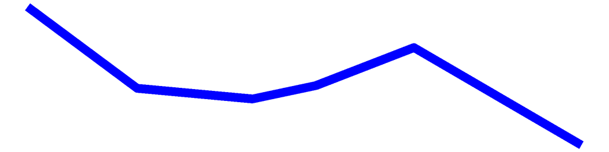

3.32106618

3.3

Surface TP (mg/L)

0.016

0.012

0.013

0.009

0.011

0.026

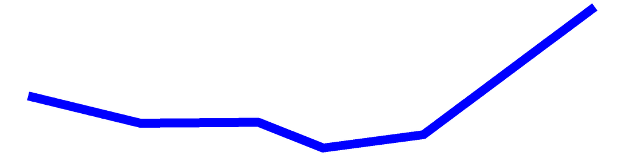

0.02019424

0.015

Surface TDP (mg/L)

0.006

0.006

0.009

0.004

0.006

0.007

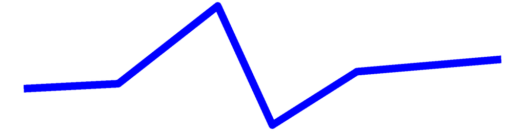

0.006

Deep TP (mg/L)

0.108

0.121

0.164

0.163

0.39

0.247

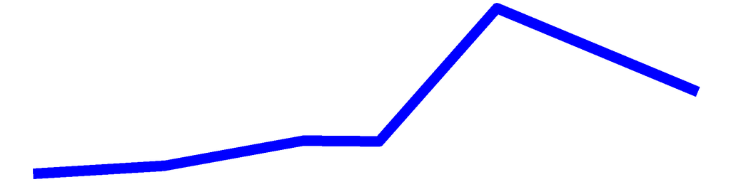

0.29773980

0.199

Deep TDP (mg/L)

0.018

0.029

0.015

0.02

0.053

0.04

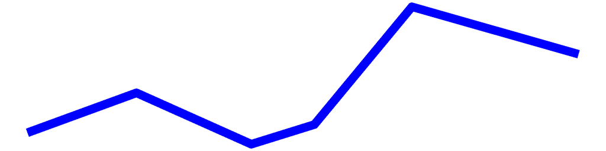

0.029

TN (mg/L)

0.393

0.437

0.448

0.418

0.352

0.41

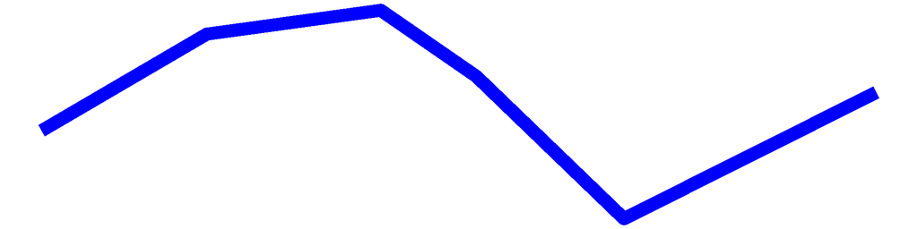

0.45053663

0.41

TDN (mg/L)

0.412

0.429

0.454

0.409

0.357

0.433

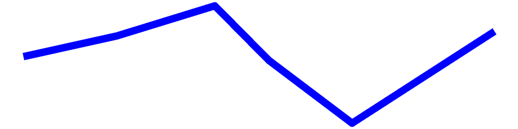

0.27400000

0.416

TN:TP

25

35

36

44

32

15

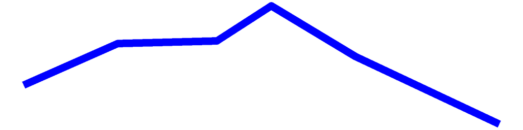

31

Surface NH3 (mg/L)

0.045

0.031

0.005

0.005

0.005

0.011

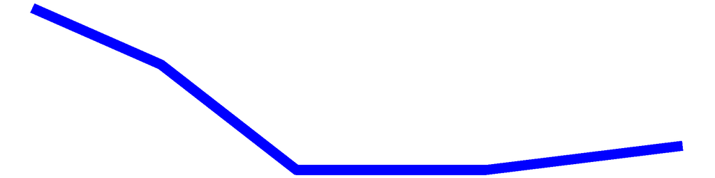

0.02536783

0.017

Deep NH3 (mg/L)

0.467

0.421

0.584

0.479

1.39

0.525

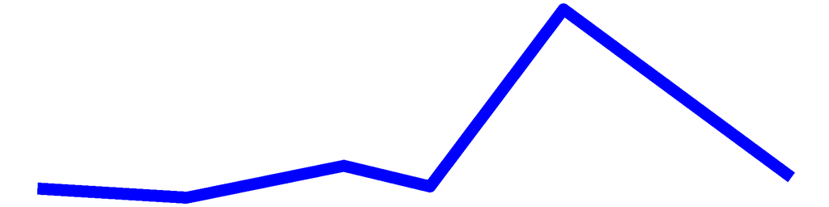

0.98938596

0.644

Chl.a (ug/L)

3.4

2.2

3

4.2

3.9

20.7

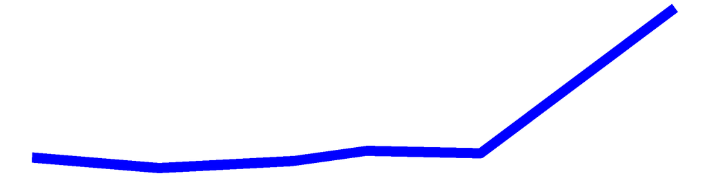

5.89114245

6.2

pH

7.7

8.1

7.7

7.7

7.7

7.6

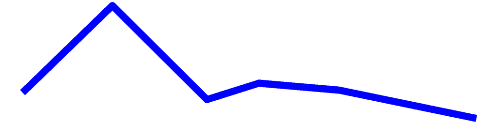

7.61154930

7.7

Cond (umho/cm)

207

221

235

236

224

188

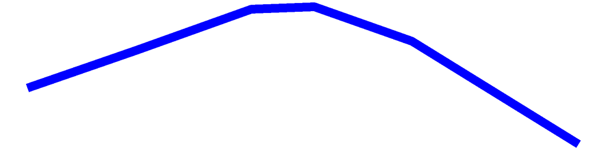

159.32560284

219

Surface Chloride (mg/L)

22

15.96666667

22

Upper Temp (degC)

23

26

28

28

28

23

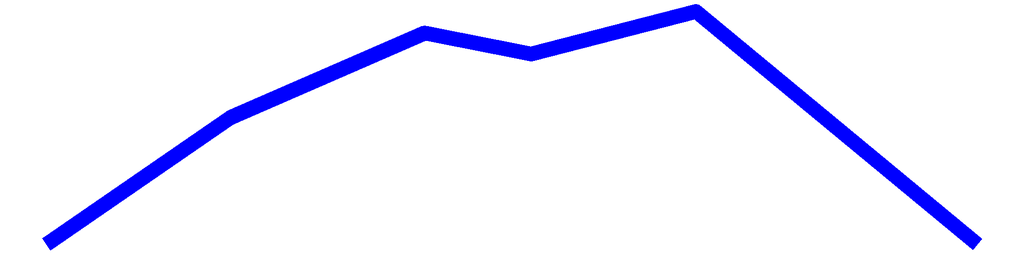

24.62181970

26

Deep Temp (degC)

10

10

11

12

12

12

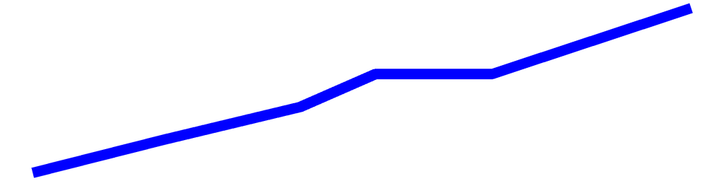

13.18092105

11

FP BG Chl.a (ug/L)

3.8

9.5

7.2

10.8

4.9

23

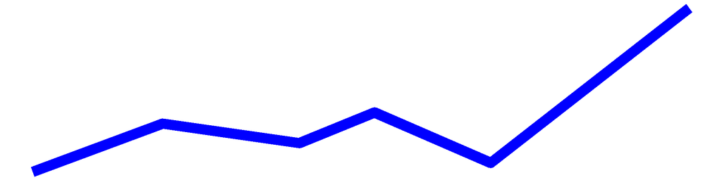

9.9

## Sepasco Lake – Sampling Season Results

### HABs Status

#### Open Water Algae

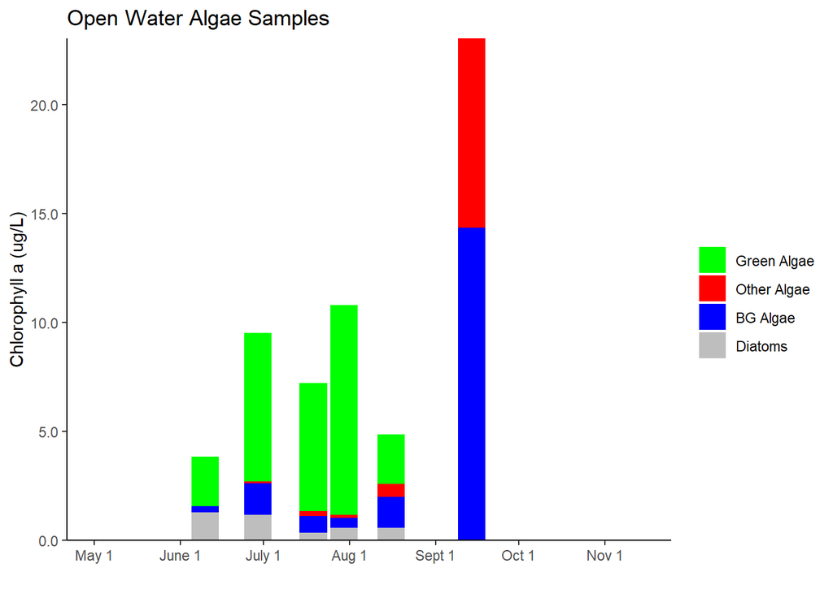

## Sepasco Lake Long-Term Trend Analysis

#### Clarity

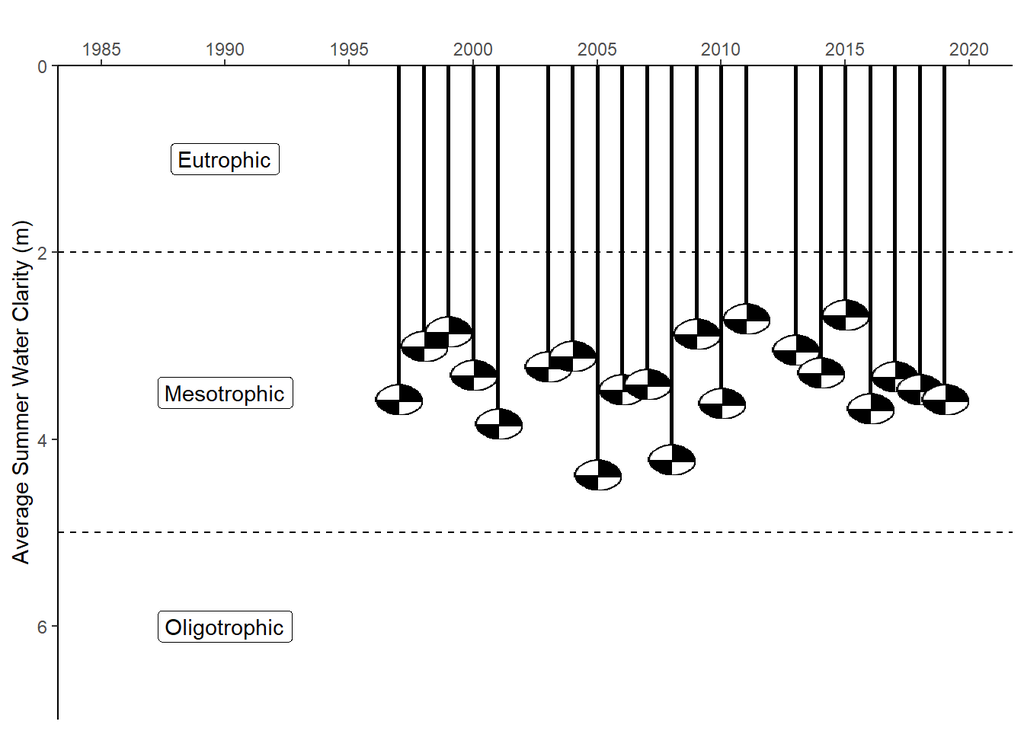

#### Chlorophyll *a*

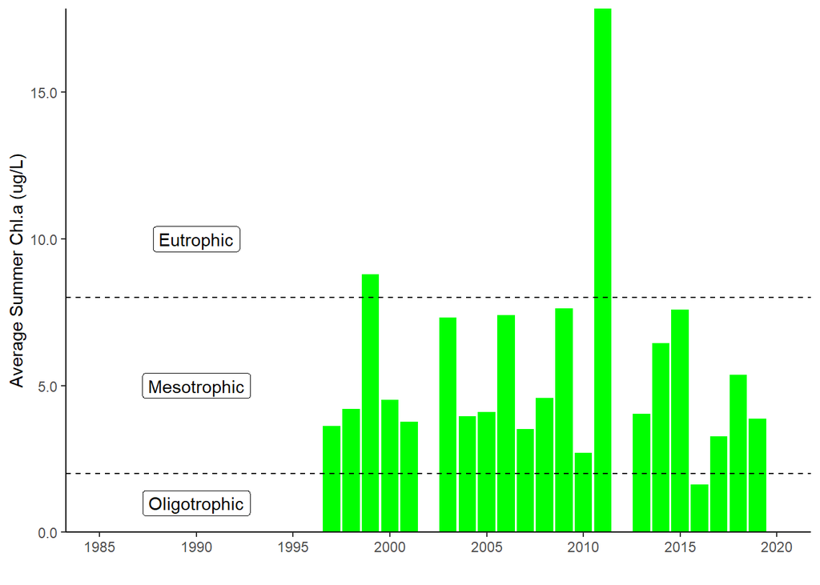

#### Surface and Deep Phosphorus

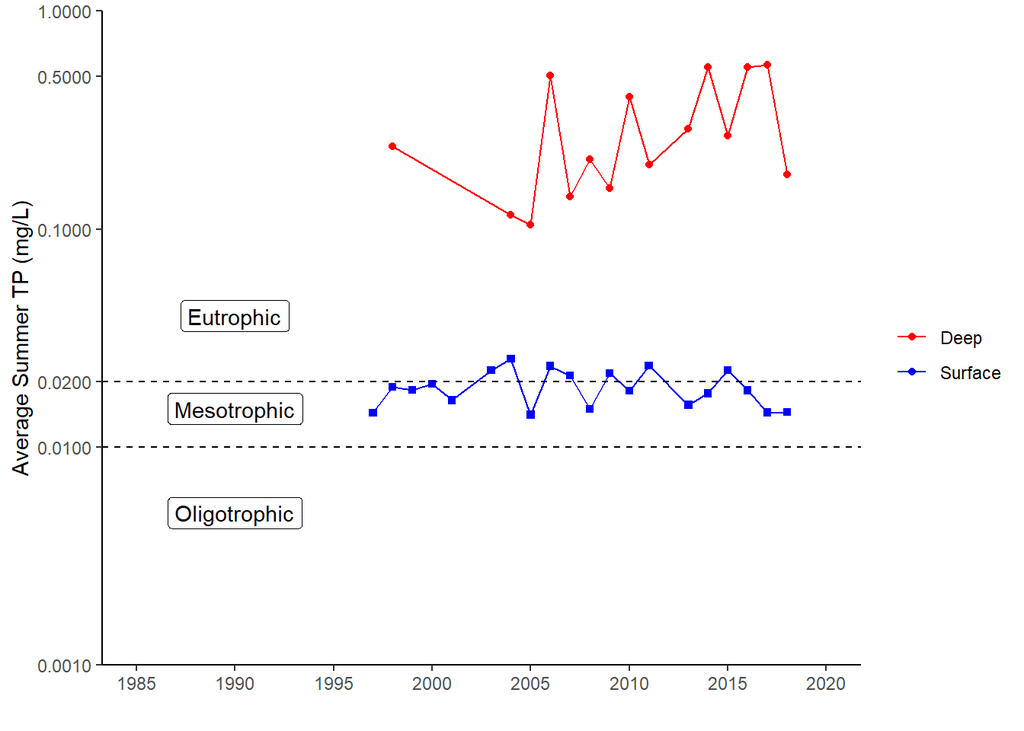

#### Nitrogen

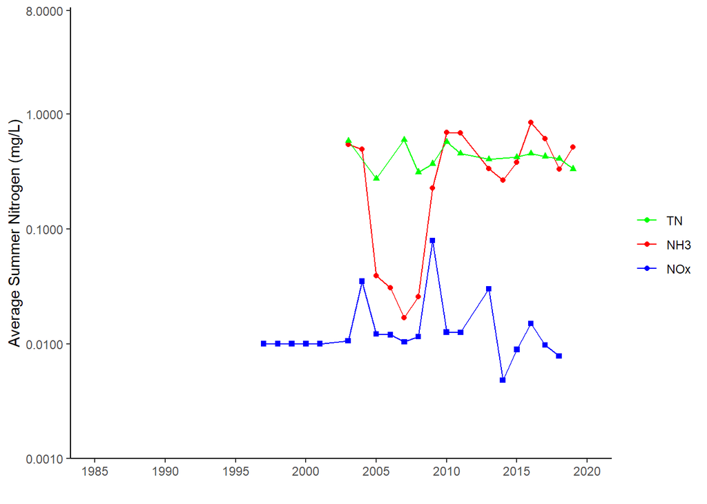

#### TN : TP

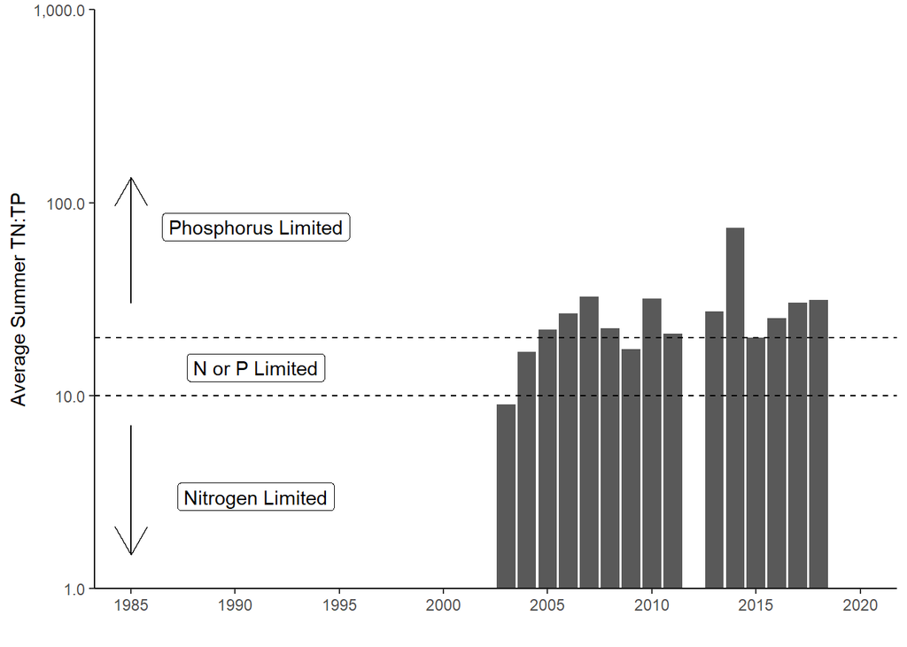

#### pH

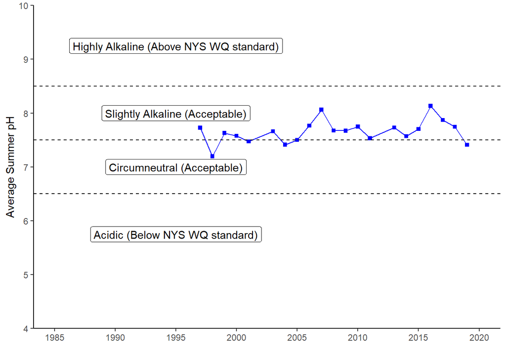

#### Specific Conductance

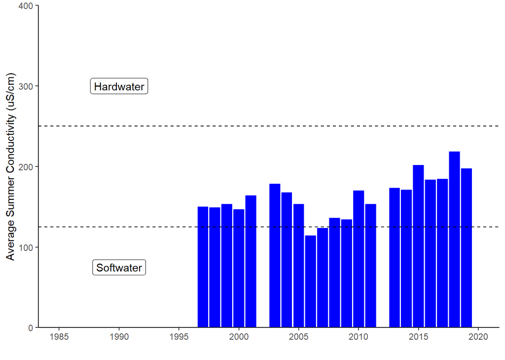

#### Calcium

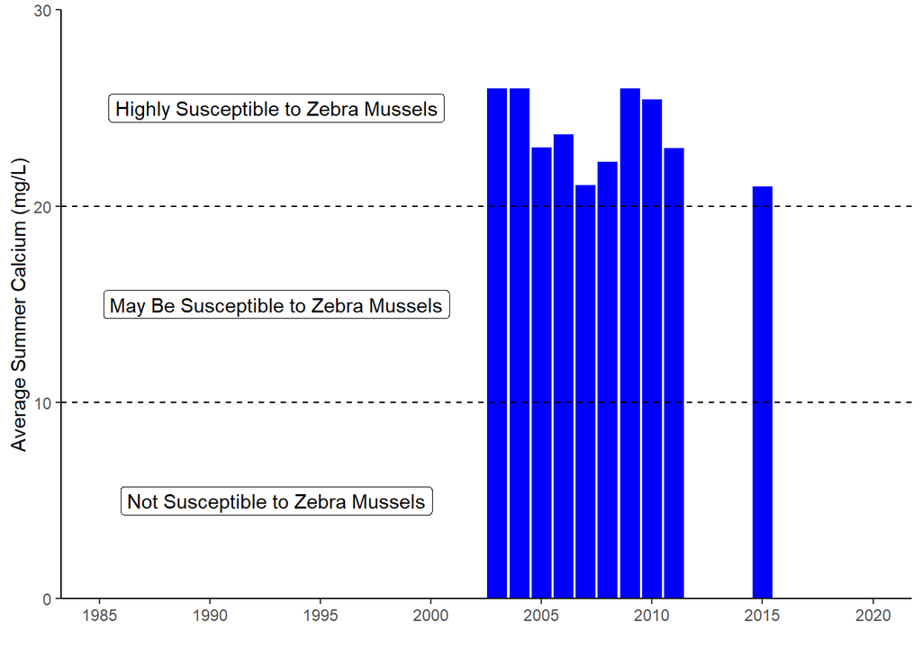

#### Chloride

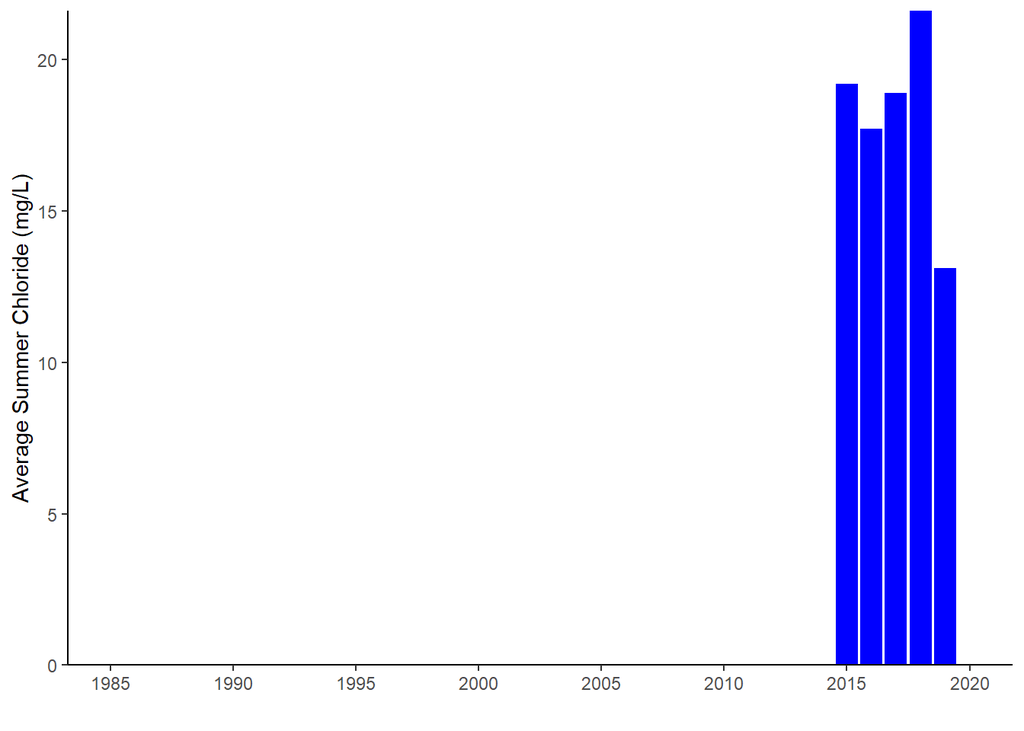

#### Color

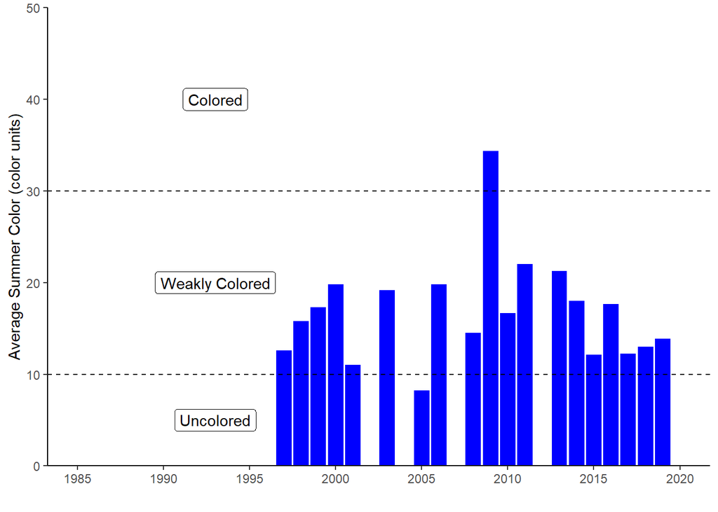

#### Surface and Deep Temperature

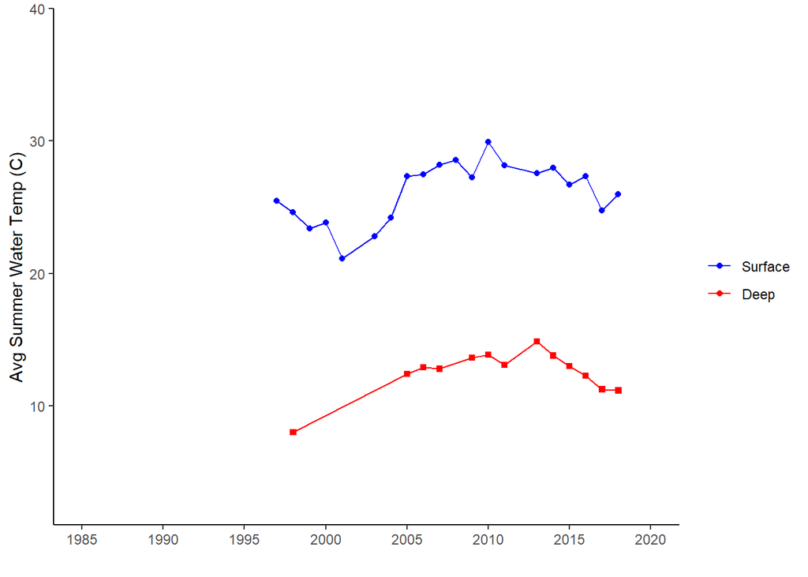

#### Lake Perception

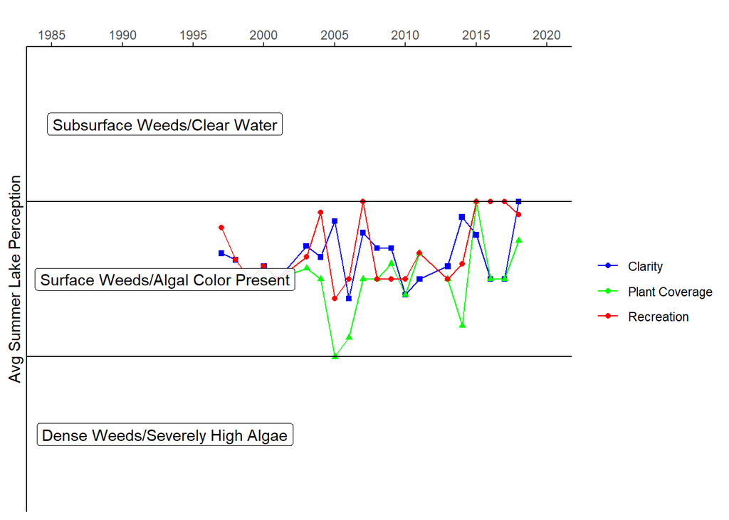

## Sepasco Lake - In-Season Analysis

#### In Season Water Clarity

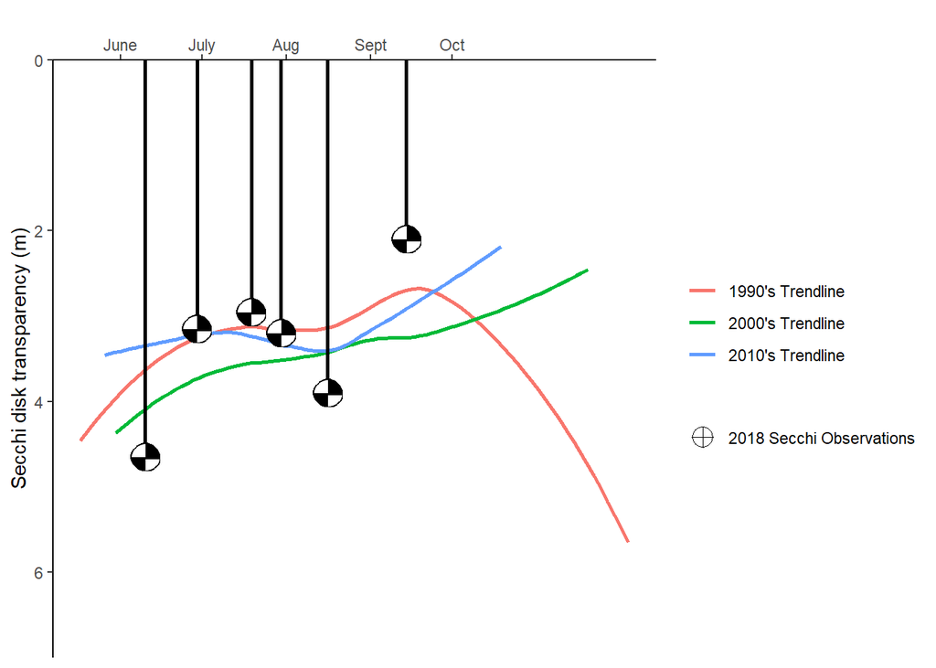

#### In Season Water Temperature

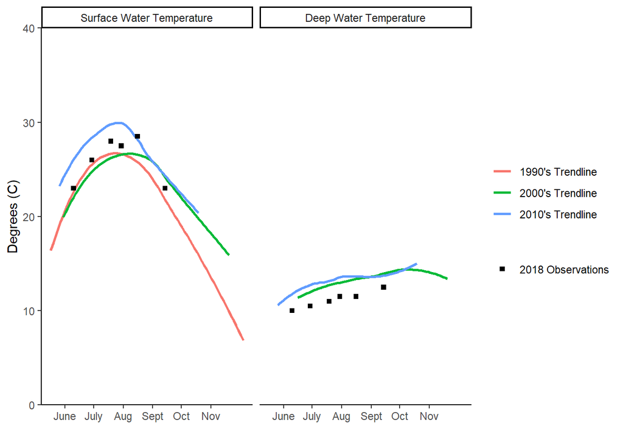